# Apprentissage Statistique

## 2.5 Weighted Decision tree

An alternative to resampling the data is to make the classifier aware of the imbalanced data by incorporating the weights of the classes into a cost function. This methods aims therefore to assign the minority class with a higher weight, and the majority class with a lower weight.

```r
set.seed(777)

K5_CV <- trainControl(method = "cv", number = 5, classProbs = TRUE,
                           savePredictions = TRUE, seeds = rcvSeeds,
                           allowParallel = TRUE, summaryFunction =  twoClassSummary)

# class weights
k <- .5
classWeights <- ifelse(bank_train$resp == "yes",
                       (1/table(bank_train$resp)[1]) * k,
                       (1/table(bank_train$resp)[2]) * (1-k))


# Parameter tuning
#grid <- expand.grid(cp = seq(from = 0.001, to = 0.005, by = 0.001))
grid <- expand.grid(cp = .02)

# Model
WDTree <- train(resp ~ .,
               data = bank_train,
               method = "rpart",
               tuneGrid = grid,
               trControl = K5_CV,
               weights = classWeights)

# Model performances
WDTree_pred <- predict(WDTree, newdata = bank_test)

confus_WDTree <- confusionMatrix(data = WDTree_pred, reference = bank_test$resp,
                       positive="yes", mode = "everything")

confus_WDTree
```

```
## Confusion Matrix and Statistics
##
##           Reference
## Prediction   yes    no
##        yes  1335  2366
##        no    893 14874
##
##                Accuracy : 0.8326
##                  95% CI : (0.8273, 0.8378)
##     No Information Rate : 0.8856
##     P-Value [Acc > NIR] : 1
##
##                   Kappa : 0.3587
##
##  Mcnemar's Test P-Value : <2e-16
##
##             Sensitivity : 0.59919
##             Specificity : 0.86276
##          Pos Pred Value : 0.36071
##          Neg Pred Value : 0.94336
##               Precision : 0.36071
##                  Recall : 0.59919
##                      F1 : 0.45033
##              Prevalence : 0.11444
##          Detection Rate : 0.06857
##    Detection Prevalence : 0.19011
##       Balanced Accuracy : 0.73098
##
##        'Positive' Class : yes
##
```

## 2.6 Random Forest

Although random forest have shown effective on a wide range of different predictive modeling problems, the use of this later is not suitable when dealing with classification problems where the class distribution is not well balanced. Nevertheless, the use of the modifications we tried with the other models (resampling & class weighting) can make it better suited to face severe class imbalance.

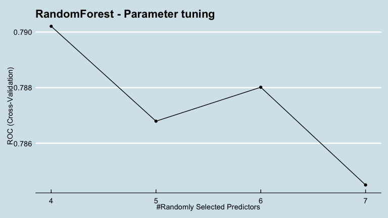

```r
# set.seed(777)
#
# K5_CV <- trainControl(method = "cv", number = 5, classProbs = TRUE,
#                       savePredictions = TRUE, summaryFunction =  twoClassSummary,
#                       seeds = rcvSeeds, allowParallel = TRUE, verboseIter = FALSE,
#                       sampling = "smote")
#
# # Parameters tuning
# Grid <- expand.grid(.mtry= c(4, 5, 6, 7))
#
# # Model
# rf2 <- train(resp ~ .,
#             data = bank_train,
#             method = "rf",
#             tuneGrid = Grid,
#             trControl = K5_CV)
#
#
# saveRDS(rf2, "/Users/.../rf_tune.rds")


githubURL <- "https://raw.githubusercontent.com/lavergnetse/Data/master/rf_tune.rds"
rf_tune <- readRDS(url(githubURL))

ggplot(rf_tune) +
  ggtitle("RandomForest - Parameter tuning") +
  theme_economist()
```

```r
# set.seed(777)
#
# # Parameters tuning
# Grid <- expand.grid(.mtry= 4)
#
# # Model
# rf <- train(resp ~ .,
#             data = bank_train,
#             method = "rf",
#             tuneGrid = Grid,
#             trControl = K5_CV)
#
#
# saveRDS(rf, "/Users/.../rf_model.rds")

githubURL <- "https://raw.githubusercontent.com/lavergnetse/Data/master/rf_model.rds"
rf <- readRDS(url(githubURL))

# Model performances
rf_pred <- predict(rf, newdata = bank_test)

confus_rf <- confusionMatrix(data = rf_pred, reference = bank_test$resp,
                       positive="yes", mode = "everything")

confus_rf
```

```
## Confusion Matrix and Statistics
##
##           Reference
## Prediction   yes    no
##        yes  1201  1407
##        no   1027 15833
##
##                Accuracy : 0.875
##                  95% CI : (0.8702, 0.8796)
##     No Information Rate : 0.8856
##     P-Value [Acc > NIR] : 1
##
##                   Kappa : 0.4258
##
##  Mcnemar's Test P-Value : 1.565e-14
##
##             Sensitivity : 0.53905
##             Specificity : 0.91839
##          Pos Pred Value : 0.46051
##          Neg Pred Value : 0.93909
##               Precision : 0.46051
##                  Recall : 0.53905
##                      F1 : 0.49669
##              Prevalence : 0.11444
##          Detection Rate : 0.06169
##    Detection Prevalence : 0.13396
##       Balanced Accuracy : 0.72872
##
##        'Positive' Class : yes
##
```

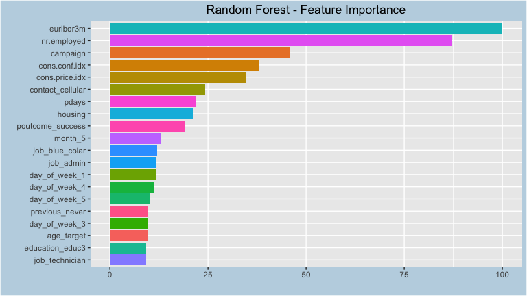

## 2.7 XGBoost

Gradient Boosting Machines presents the advantage to deal with class imbalance by constructing successive training sets based on incorrectly classified examples. Therefore they usually outperforms other three-based methods on imbalanced dataset:

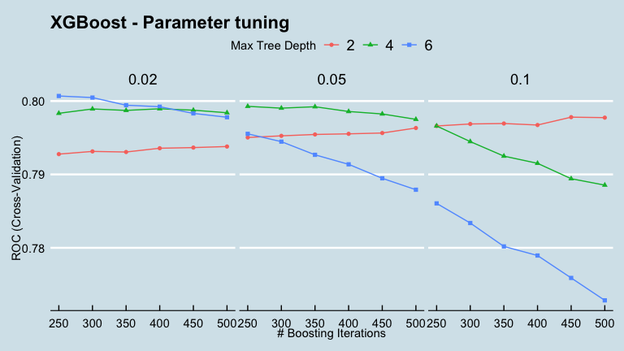

```r
# set.seed(777)
#
# K5_CV <- trainControl(method = "cv", number = 5, classProbs = TRUE,
#                       savePredictions = TRUE, summaryFunction =  twoClassSummary,
#                       seeds = rcvSeeds, allowParallel = TRUE, verboseIter = FALSE,
#                       sampling = "smote")
#
#
# grid = expand.grid(nrounds = seq(from = 250, to = 500, by = 50),
#                         eta = c(0.02, 0.05, 0.1),
#                         max_depth = c(2, 4, 6),
#                         gamma = .1,
#                         colsample_bytree = 0.75,
#                         min_child_weight = 3,
#                         subsample = 0.5)
#
#
# xgb_tune  <-  train(x = bank_train[, -50],
#                y = bank_train$resp,
#                method = "xgbTree",
#                bag.fraction = 0.6,
#                trControl = K5_CV,
#                tuneGrid = grid)
#
# saveRDS(xgb_tune, "/Users/.../xgb_model.rds")


githubURL <- "https://raw.githubusercontent.com/lavergnetse/Data/master/xgb_model.rds"
xgb_tune <- readRDS(url(githubURL))

ggplot(xgb_tune) +
  ggtitle("XGBoost - Parameter tuning") +
  theme_economist()
```

By looking at this graph, we can see that the best ROC is obtained with a maximum tree depth of 6, a number of boosting iterations of 250 and a low learning rate (eta) of 0.02. However the blue curve doesn’t have a good shape: it falls downs when the number of boosting iterations increase, but also when the learning rate becomes greater. Indeed, a high value of *Max Tree Depth* can make the model to complex and more likely to overfit. That’s why in order to have a better model, one would prefer a more stable model - that is a model with the following tuning parameter :

- *eta* = 0.1
- *nrounds* = 450
- *max_depth* = 2

```r
# grid = expand.grid(nrounds = 450,
#                         eta = .1,
#                         max_depth = 2,
#                         gamma = .1,
#                         colsample_bytree = 0.75,
#                         min_child_weight = 3,
#                         subsample = 0.5)
#
# xgb  <-  train(x = bank_train[, -50],
#                y = bank_train$resp,
#                method = "xgbTree",
#                trControl = K5_CV,
#                tuneGrid = grid,
#                verbose = F)
#
# saveRDS(xgb, "/Users/.../xgb_fit.rds")

githubURL <- "https://raw.githubusercontent.com/lavergnetse/Data/master/xgb_fit.rds"
xgb <- readRDS(url(githubURL))

# Model performances
xgb_pred <- predict(xgb, newdata = bank_test)

confus_xgb <- confusionMatrix(data = xgb_pred, reference = bank_test$resp,
                       positive="yes", mode = "everything")

confus_xgb
```

```
## Confusion Matrix and Statistics
##
##           Reference
## Prediction   yes    no
##        yes  1028  1049
##        no   1200 16191
##
##                Accuracy : 0.8845
##                  95% CI : (0.8799, 0.8889)
##     No Information Rate : 0.8856
##     P-Value [Acc > NIR] : 0.686603
##
##                   Kappa : 0.4127
##
##  Mcnemar's Test P-Value : 0.001562
##
##             Sensitivity : 0.4614
##             Specificity : 0.9392
##          Pos Pred Value : 0.4949
##          Neg Pred Value : 0.9310
##               Precision : 0.4949
##                  Recall : 0.4614
##                      F1 : 0.4776
##              Prevalence : 0.1144
##          Detection Rate : 0.0528
##    Detection Prevalence : 0.1067
##       Balanced Accuracy : 0.7003
##
##        'Positive' Class : yes
##
```

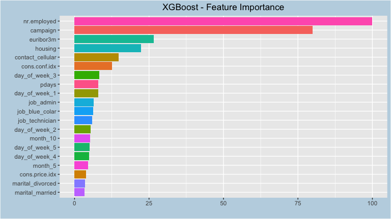

## 2.8 SVM

The Support Vector Machine (SVM) is a useful classification technique. As you know in real life data the separation boundary is generally non-linear, and the SVM algorithm allows to perform a non-linear classification using what is called the “*kernel trick*”. There are several kernel transformations, but the two most commonly used are the **polynomial** and **radial** kernel.

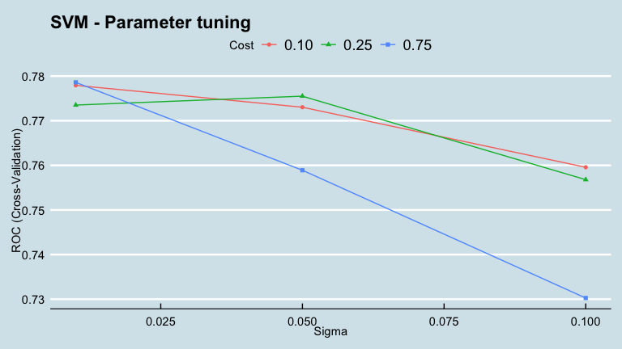

```r
# set.seed(777)
#
# registerDoParallel(cl)
#
# K5_CV <- trainControl(method = "cv", number = 5, classProbs = TRUE,
#                       savePredictions = TRUE, summaryFunction =  twoClassSummary,
#                       seeds = rcvSeeds, allowParallel = TRUE, verboseIter = FALSE,
#                       sampling = "smote")
#
#
# # Parameter tuning
# grid <- expand.grid(C = c(0.1, 0.25, 0.75),
#                     sigma = c(0.01, 0.05, 0.1))
#
# # Model
# svm1 <- train(resp ~ . ,
#              data = bank_train,
#              method = "svmRadial",                # Radial Kernel
#              preProcess = c("center","scale"),
#              trControl = K5_CV,
#              tuneGrid = grid)
#
# saveRDS(svm1, "/Users/.../svm1_model.rds")


githubURL <- "https://raw.githubusercontent.com/lavergnetse/Data/master/svm1_model.rds"
svm_tune <- readRDS(url(githubURL))

ggplot(svm_tune) +
  ggtitle("SVM - Parameter tuning") +
  theme_economist()
```

```r
# set.seed(777)
#
# registerDoParallel(cl)
#
# K5_CV <- trainControl(method = "cv", number = 5, classProbs = TRUE,
#                       savePredictions = TRUE, summaryFunction =  twoClassSummary,
#                       seeds = rcvSeeds, allowParallel = TRUE, verboseIter = FALSE,
#                       sampling = "smote")
#
#
# # Parameter tuning
# grid <- expand.grid(C = .75,
#                     sigma = .01)
#
# # Model
# svm <- train(resp ~ . ,
#              data = bank_train,
#              method = "svmRadial",                # Radial Kernel
#              preProcess = c("center","scale"),
#              trControl = K5_CV,
#              tuneGrid = grid)
#
# saveRDS(svm, "/Users/.../svm_fit.rds")

githubURL <- "https://raw.githubusercontent.com/lavergnetse/Data/master/svm_fit.rds"
svm <- readRDS(url(githubURL))

# Model performances
svm_pred <- predict(svm, newdata = bank_test)

confus_svm <- confusionMatrix(data = svm_pred, reference = bank_test$resp,
                       positive="yes", mode = "everything")

confus_svm
```

```
## Confusion Matrix and Statistics
##
##           Reference
## Prediction   yes    no
##        yes  1300  1788
##        no    928 15452
##
##                Accuracy : 0.8605
##                  95% CI : (0.8555, 0.8653)
##     No Information Rate : 0.8856
##     P-Value [Acc > NIR] : 1
##
##                   Kappa : 0.4107
##
##  Mcnemar's Test P-Value : <2e-16
##
##             Sensitivity : 0.58348
##             Specificity : 0.89629
##          Pos Pred Value : 0.42098
##          Neg Pred Value : 0.94335
##               Precision : 0.42098
##                  Recall : 0.58348
##                      F1 : 0.48909
##              Prevalence : 0.11444
##          Detection Rate : 0.06678
##    Detection Prevalence : 0.15862
##       Balanced Accuracy : 0.73989
##
##        'Positive' Class : yes
##
```

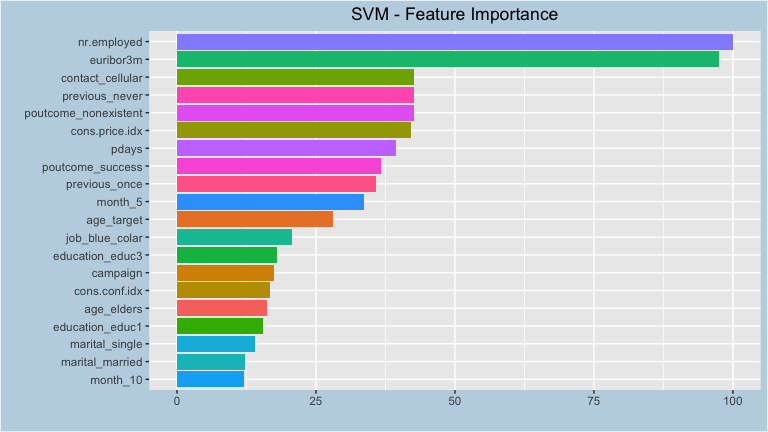

# 3 Model comparison

We tried a lot of different model to predict if a client will subscribe a term deposit. Although they perform in a different way, each of these models seem to present different but quite similar results on unseen data. So let’s evaluate them by looking at the different metrics they present, like sensitivity, ROC, F1 score or Gini coefficient, such metrics that perform better in evaluating model performance for imbalanced datasets.

## 3.1 Sensitivity

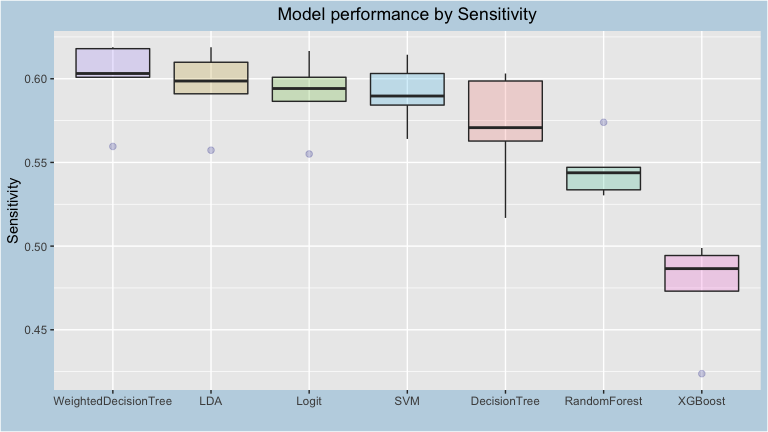

```r
models <- list(Logit = logit3,
               LDA = lda,
               DecisionTree = DTree,
               WeightedDecisionTree = WDTree,
               RandomForest = rf,
               XGBoost = xgb,
               SVM = svm)

res <- resamples(models)

models_list <- c("Logit",
                 "LDA",
                 "DecisionTree",
                 "WeightedDecisionTree",
                 "RandomForest",
                 "XGBoost",
                 "SVM")

df = data.frame()
for (i in models_list){
  x = data.frame (model = i,
                  Sens = res$values[paste(i,"Sens", sep = "~")],
                  ROC = res$values[paste(i,"ROC", sep = "~")])
  x <- x %>% rename(Sens = paste(i,"Sens", sep = "."))
  x <- x %>% rename(ROC = paste(i,"ROC", sep = "."))
  df <- rbind(df,x)
}

# Sensitivity
ggplot(data = df, aes(x = fct_reorder(model, Sens, .desc = T),
                      y = Sens, fill = model)) +
  geom_boxplot(outlier.colour = "darkblue", outlier.size = 2, alpha=0.2) +
  theme_model +
  labs(x = "", y = "Sensitivity") +
  ggtitle("Model performance by Sensitivity")
```

## 3.2 F1 score

As explained at the beginning, this metrics can be considered as the harmonic mean of the precision and the sensitivity. The closer it is to 1, the better the precision & sensitivity.

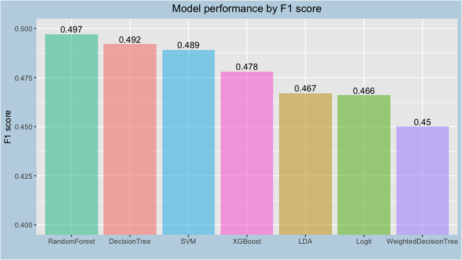

```r
# Extract the F1 score from the confusion matrix
F1 <- c(confus_logit$byClass[7],
        confus_lda$byClass[7],
        confus_DTree$byClass[7],
        confus_WDTree$byClass[7],
        confus_rf$byClass[7],
        confus_xgb$byClass[7],
        confus_svm$byClass[7])

F1_table <- data.frame(model = models_list,
           F1_score = F1)

# Keep only 3 digits
F1_table$F1_score <- round(F1_table$F1_score,3)


ggplot(data = F1_table,
       aes(x = fct_reorder(model, F1_score, .desc = T),
           y = F1_score,
           fill = model)) +
  geom_bar(stat = "identity", alpha=0.5) +
  labs(x = "", y = "F1 score") +
  geom_text(aes(label = F1_score, vjust = -0.3)) +
  theme_model +
  ggtitle("Model performance by F1 score") +
  coord_cartesian(ylim=c(.4, .5))
```

If the *WeightedDecisionTree* presents the best sensitivity, it is also because this model predict much more positive values (client with *resp* = “yes”). Thus the precision of this model is among the worst of the tested model (0.36), which lead to a poor F1 score, whose highest value is obtained with the *RandomForest* model (0.497).

However if we look at both sensitivity & F1 score performances, we can see that the *SVM* model is the more accurate.

## 3.3 ROC & Gini coefficient

If the two first metrics we’ve just studied focused only on the positive prediction, the ROC allows to visualize the trade-off between the true positive rate and the false positive rate.

But before plotting the ROC, we can have a look on the Gini coefficient which is a popular metric for imbalanced class values. It is calculated as follows : $(2 \times AUC) - 1$.

This coefficient represents how close is a model to being a “perfect classifier” (represented by a Gini coefficient of 1). At the opposite, a “random classifier” would get a Gini coefficient of 0.

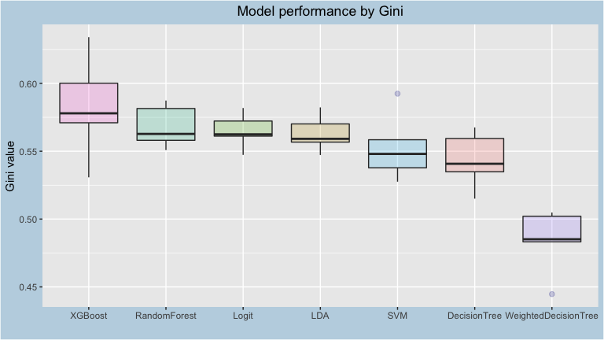

```r
# Compute Gini coefficient
df$Gini <- (2*df$ROC) - 1

# Gini value
ggplot(data = df, aes(x = fct_reorder(model, Gini, .desc = T),
                      y = Gini, fill = model)) +
  geom_boxplot(outlier.colour = "darkblue", outlier.size = 2, alpha=0.2) +
  theme_model +
  labs(x = "", y = "Gini value") +
  ggtitle("Model performance by Gini")
```

For the first time, it is the Boosting based method which best perform. The value can be interpreted as the probability that a random positive observation will have a higher estimated probability than a random negative observation: it tells how much a model is able to distinguishing between classes.

So let’s plot the curves to see their shape:

> A perfect classifier have its ROC curve that form a right angle - that is the curve go along the Y-axis and then along the X-axis.

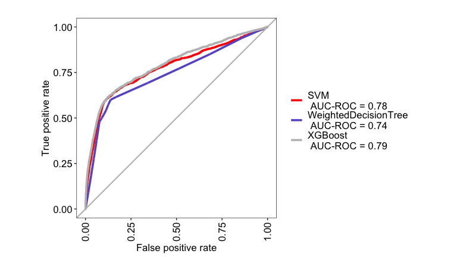

```r
library(MLeval)

# For the sake of visibility, we only present 3 models
roc <- evalm(list(svm, WDTree, xgb), gnames=c('SVM',
                                              'WeightedDecisionTree',
                                              'XGBoost'),
             silent=TRUE, positive = "yes", plots="r")
```

Regarding the Gini coefficient, it could be interpreted as the ratio between the area within the ROC curve and the random model line (represented by the diagonal line), and the area between the perfect classifier curve and the random model line.

## 3.4 Balanced Accuracy

A latest metric and maybe the more evident is the balanced accuracy, which is computed as the average of the correct predictions of each class individually: $(Sensitivity + Specificity) / 2$.

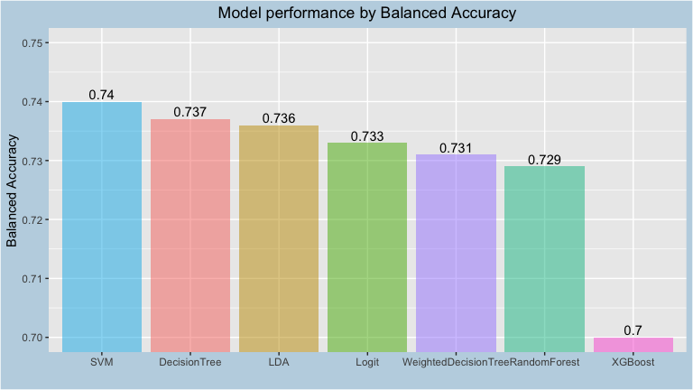

```r
# Extract the Balanced Accuracy from the confusion matrix
Balanced_Acc <- c(confus_logit$byClass[11],
        confus_lda$byClass[11],
        confus_DTree$byClass[11],
        confus_WDTree$byClass[11],
        confus_rf$byClass[11],
        confus_xgb$byClass[11],
        confus_svm$byClass[11])

BalancedAcc_table <- data.frame(model = models_list,
           Balanced_Accuracy = Balanced_Acc)

# Keep only 3 digits
BalancedAcc_table$Balanced_Accuracy <- round(BalancedAcc_table$Balanced_Accuracy,3)


ggplot(data = BalancedAcc_table,
       aes(x = fct_reorder(model, Balanced_Accuracy, .desc = T),
           y = Balanced_Accuracy,
           fill = model)) +
  geom_bar(stat = "identity", alpha=0.5) +
  labs(x = "", y = "Balanced Accuracy") +
  geom_text(aes(label = Balanced_Accuracy, vjust = -0.3)) +
  theme_model +
  ggtitle("Model performance by Balanced Accuracy") +
  coord_cartesian(ylim=c(.7, .75))
```

Except *XGBoost*, all the model are pretty close from each other, but the SVM one with radial kernel has the best balanced accuracy (0.74), and is therefore the model that give the best prediction in a general way.

Finally by looking at every metrics, we can also highlight the good performances obtained by the Logistic approach & the Linear Discriminant Analysis.

Well, this concludes this project. For sure there are other ways to treat this subject, but we presented here a general approach, which can serve as basis for other projects.